# Structuring HitBeats

Currently, we have `HitBeat` scenes that spawn randomly across the screen.

All the gameplay functionality is there; they spawn in time with the track’s beats-per-minute, the player can time their taps for a variable score, and we have nice visuals and feedback.

We just need to structure this chaos!

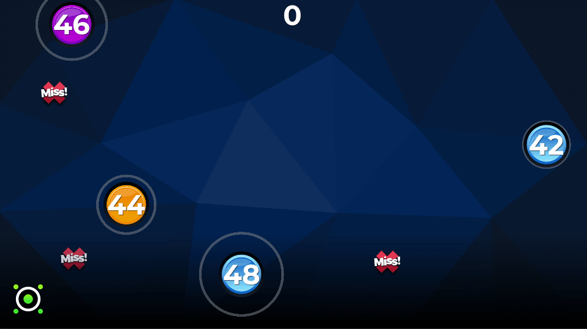

In this lesson, we’ll create a system within the Godot editor which we’ll use to design **patterns** for the player.

These patterns are made up of `HitBeat` instances that appear at a specific time and position on the screen. We’ll then design a simple pattern for the *Cephalopod* track.

I’ll leave creating patterns for the other tracks to you.

We *could* create a custom-made plugin to use within Godot where we could draw the desired pattern. This would be a good investment if you decided to develop a commercial rhythm game.

But this is also time-consuming and beyond this tutorial’s scope. For now, Godot scenes will do just fine.

By designing patterns, we can make the player more engaged with the music. For example, we could design an ascending pattern in the editor that corresponds to the music rising in pitch.

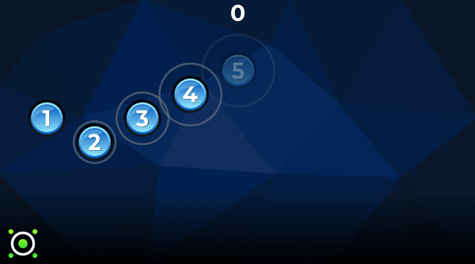

Mirroring the music track in this way is what makes rhythm games so fun! It’s up to us to fit these `HitBeat` patterns with the music, but we have to create the tools to do it first.

## The HitBeat stack

Thanks to the `Synchronizer`, we already have a marker for each half-beat as a track plays.

To determine whether we instance a `HitBeat` on any given half-beat, we’ll have a stack (array) of instructions stored in the `HitSpawner`.

Every time the `Events.beat_incremented` signal fires, the `HitSpawner` will grab the next instruction and either instance a `HitBeat` or do nothing.

We’ll also use scenes to visually design patterns and create unique stacks for each track. But first, let’s hard-code a simple pattern so you can see how this stack approach works.

The `_generate_stack()` method is temporary, for testing purposes.

[output not shown]

Now we have a stack, we’re going to rewrite `_spawn_beat()` to pop dictionaries from the `_stack_current` and process them. Replace the existing method with the following.

```
func _spawn_beat(msg: Dictionary) -> void:

    if not enabled:
        return

    # After we've processed everything in the stack, we disable the HitSpawner
    # We also emit a signal which we can use later to show an end screen
    if _stack_current.empty():
        enabled = false
        Events.emit_signal("track_finished")
        return

    # pop_front() grabs the front dictionary from the stack and also removes it
    var hit_beat_data: Dictionary = _stack_current.pop_front()

    # If the dictionary has no global_position, we skip instancing
    if not hit_beat_data.has("global_position"):
        return

    # Otherwise we add extra information as we did before and instance a HitBeat
    hit_beat_data.bps = msg.bps
    hit_beat_data.half_beat = msg.half_beat

    var new_beat: Node = hit_beat.instance()
    add_child(new_beat)
    new_beat.setup(hit_beat_data)
```

We use a new signal on `Events` in the code above. We have to define it in `Events.gd`.

```
signal track_finished
```

If you run the game, you’ll see we’ve managed to remove random positions in favor of a simple pattern the player can interact with.

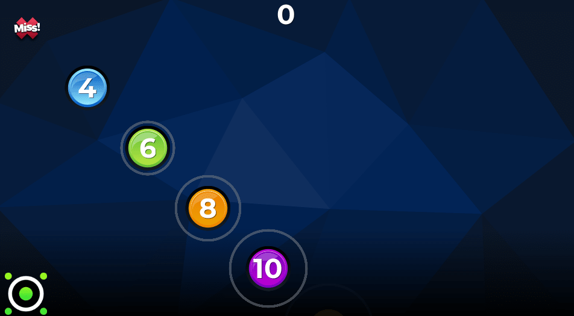

You can now delete the `_generate_stack()` function and the call to it. We used it only to illustrate and test the new approach to spawning `HitBeat` instances.

You could use code like this to programmatically create interesting patterns. To do so, you’d want to use functions like `_generate_stack()`.

Instead, though, we’ll use scenes to do so visually moving forward. In rhythm games, while you can use procedural generation for gameplay, hand-crafted levels tend to work best.

## Visually designing patterns

Let’s think about how we’d represent timing in the Godot editor.

Say we want to instance a new `HitBeat` every beat. The first four instances would look like this in musical notation, which we could represent in the editor using similar placeholder sprites.

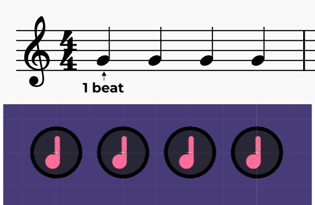

While the sheet music notation only represents timing, the sprites over the purple background will allow us to store each note’s position relative to one another.

We also need a way to represent the empty dictionaries from our example. Musically, these are called rests. In music notation, we typically represent them with a zig-zagging symbol (the symbol depends on the rest’s duration).

Likewise, we’ll use a similar sprite to represent those.

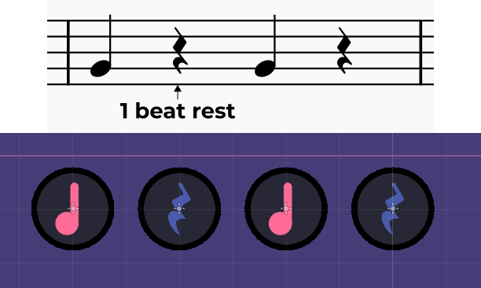

Functionally, each placeholder rest will fill the stack with several empty dictionaries, based on how many half-beats we want the player to rest.

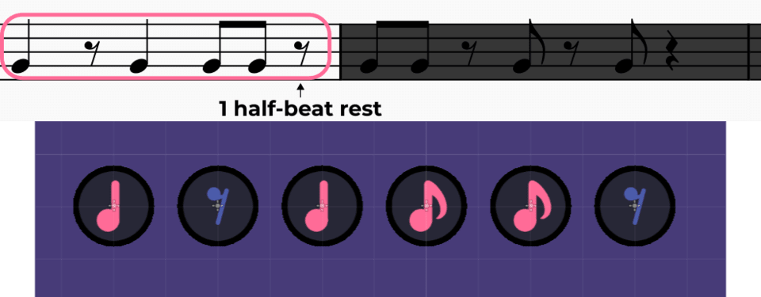

In the next lesson, we’ll create new `PlacerHitBeat` and `PlacerRest` scenes such that we can modify their duration and have placeholder sprites update automatically within the editor.

## Visually ordering the stack

To order the notes, we’ll take advantage of Godot’s scene tree.

To illustrate this, let’s take the *Cephalopod* pattern scene in the finished rhythm game demo.

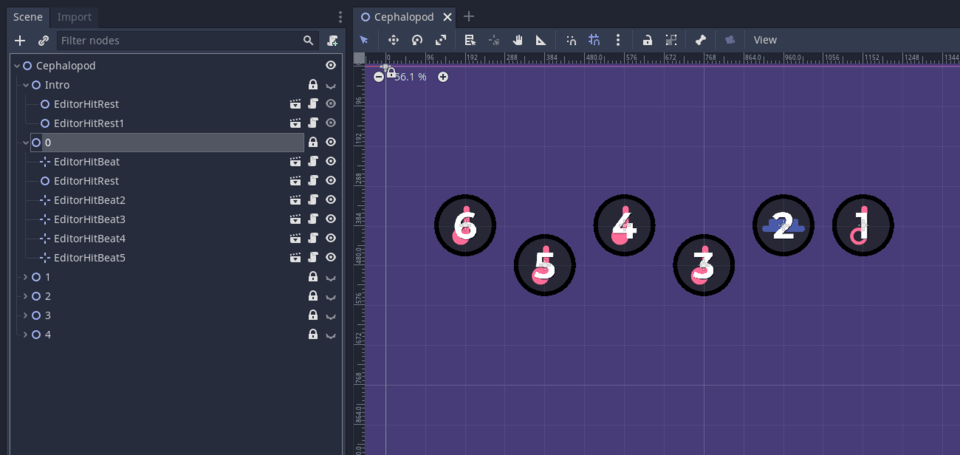

With this structure, we can systematically move down the children of *Cephalopod* and extract the information from each note or rest found there.

We split the track into chunks to make designing the overall track’s gameplay easier. That way, we can turn the visibility of entire sections of the track on or off.

Once we have all of our individual patterns for each track designed, we’ll instantiate them as children to a `Patterns` scene which the `HitSpawner` will use to gather and build the stack for each track.

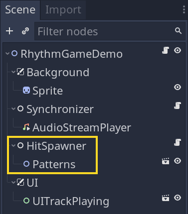

Now we know how it will work, let’s get creating! In the next lesson, we’ll create the `PlacerHitBeat` and `PlacerRest` scenes and design a short pattern for the *Cephalopod* track.

## Code reference

`HitSpawner.gd`

```
extends Node

export var enabled := true
export var hit_beat: PackedScene

var _stack_current = []


func _ready() -> void:
    Events.connect("beat_incremented", self, "_spawn_beat")


func _spawn_beat(msg: Dictionary) -> void:
    if not enabled:
        return

    if _stack_current.empty():
        enabled = false
        Events.emit_signal("track_finished")
        return

    var hit_beat_data: Dictionary = _stack_current.pop_front()

    if not hit_beat_data.has("global_position"):
        return

    hit_beat_data.bps = msg.bps
    hit_beat_data.half_beat = msg.half_beat

    var new_beat: Node = hit_beat.instance()
    add_child(new_beat)
    new_beat.setup(hit_beat_data)
```

`Events.gd`

```
extends Node

signal beat_incremented(msg)
signal scored(msg)

signal track_finished
```